# T.S Final Project

110225007房錚、110225013劉彥劭、110225021劉懿萱

2023-01-02

# 1 原始資料說明與建模流程

此次選擇標準普爾(以下SP500代稱)、日經平均指數(以下以N225代稱)、紐西蘭NZX50指數(以下NZ50代稱)，於2012-12-12至2022-12-12十年期間的股價日資料進行資料分析與建模。美金對紐西蘭匯率(以下以USDNZD代稱)、美金對日幣匯率(以下以USDJPY代稱)與紐西蘭對日本匯率(以下以NZDJPY代稱)，於2012-12-12到2022-12-12這段時間內的日資料，分別繪製其原始資料與對數報酬率的time plot、ACF與PACF，並對資料進行一階動差及二階動差Ljung Box Test，看資料是否有序列相關或Arch效應，若有序列相關或Arch效應將根據結果更進一步建立ARMA模型或Garch模型，並於建模後做殘差檢定、分析及預測。

# 2 原始資料說明與time plot、ACF、PACF繪製

## 2.1 NZ50

```
## [1] "^NZ50"
```

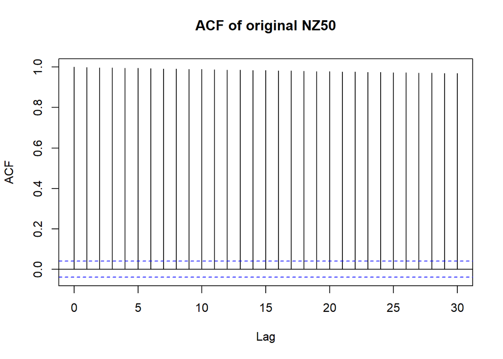

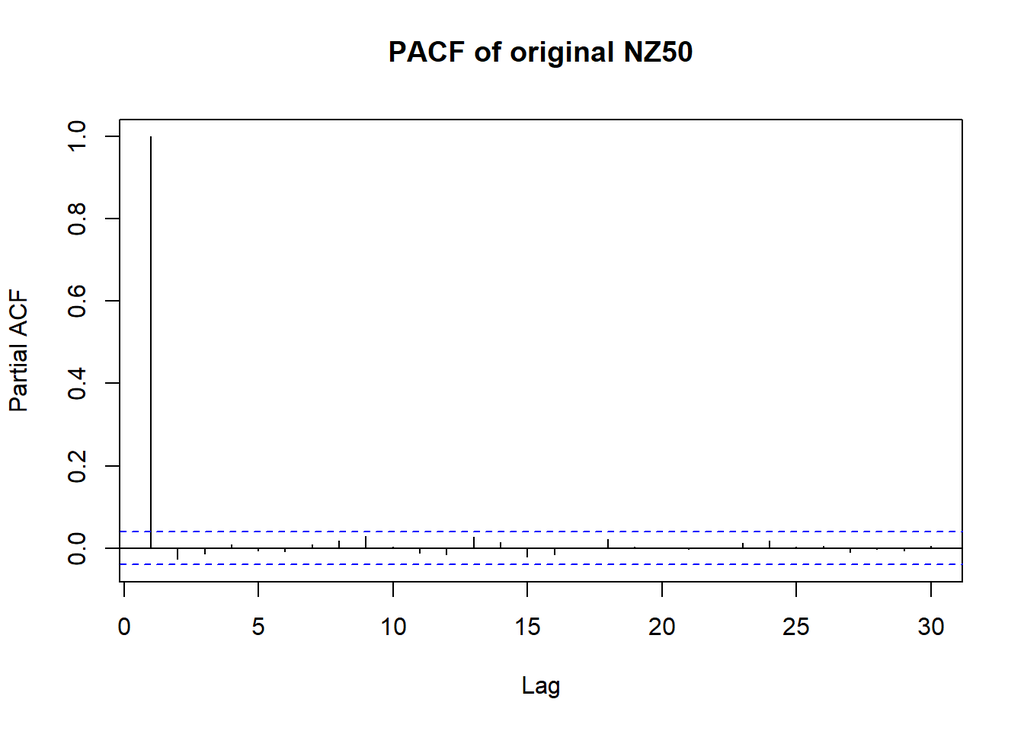

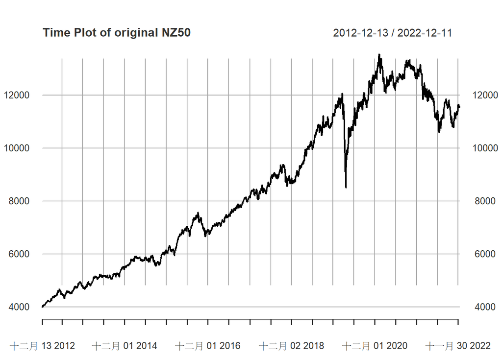

```
##
##  Box-Ljung test
##
## data:  NZ50
## X-squared = 24349, df = 10, p-value < 2.2e-16
```

```
##
##  Box-Ljung test
##
## data:  NZ50^2
## X-squared = 24348, df = 10, p-value < 2.2e-16
```

```
##
## Title:
##  Augmented Dickey-Fuller Test
##
## Test Results:
##   PARAMETER:
##     Lag Order: 1
##   STATISTIC:
##     Dickey-Fuller: -2.1989
##   P VALUE:
##     0.4941
##
## Description:
##  Mon Jan  2 16:30:42 2023 by user: User
```

## 2.2 USDNZD

```
## [1] "USDNZD=X"
```

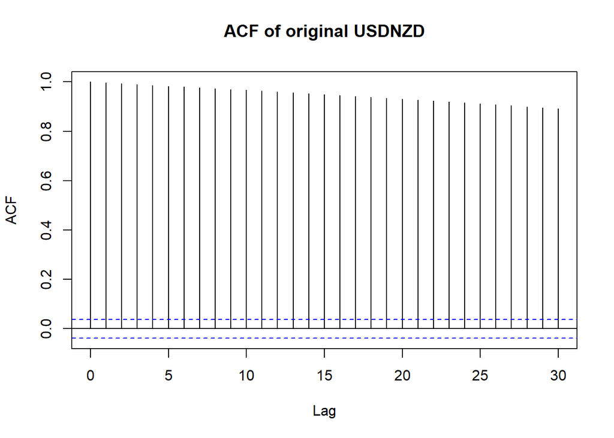

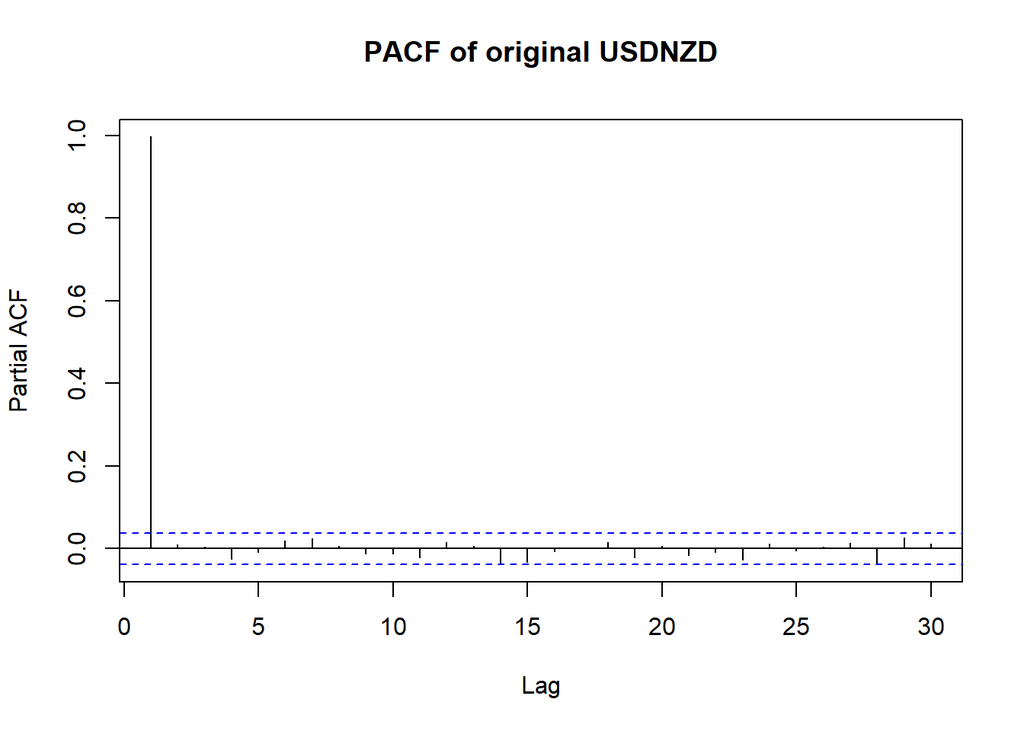

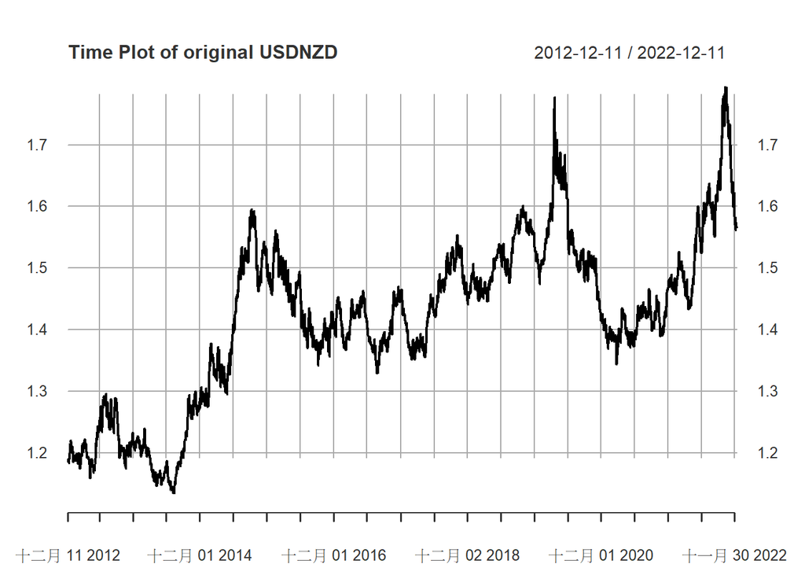

```
##
##  Box-Ljung test
##
## data:  USDNZD
## X-squared = 25167, df = 10, p-value < 2.2e-16
```

```
##
##  Box-Ljung test
##
## data:  USDNZD^2
## X-squared = 25092, df = 10, p-value < 2.2e-16
```

```
##
## Title:
##  Augmented Dickey-Fuller Test
##
## Test Results:
##   PARAMETER:
##     Lag Order: 1
##   STATISTIC:
##     Dickey-Fuller: -2.7358
##   P VALUE:
##     0.2668
##
## Description:
##  Mon Jan  2 16:30:43 2023 by user: User
```

## 2.3 S&P500

```
## [1] "^GSPC"
```

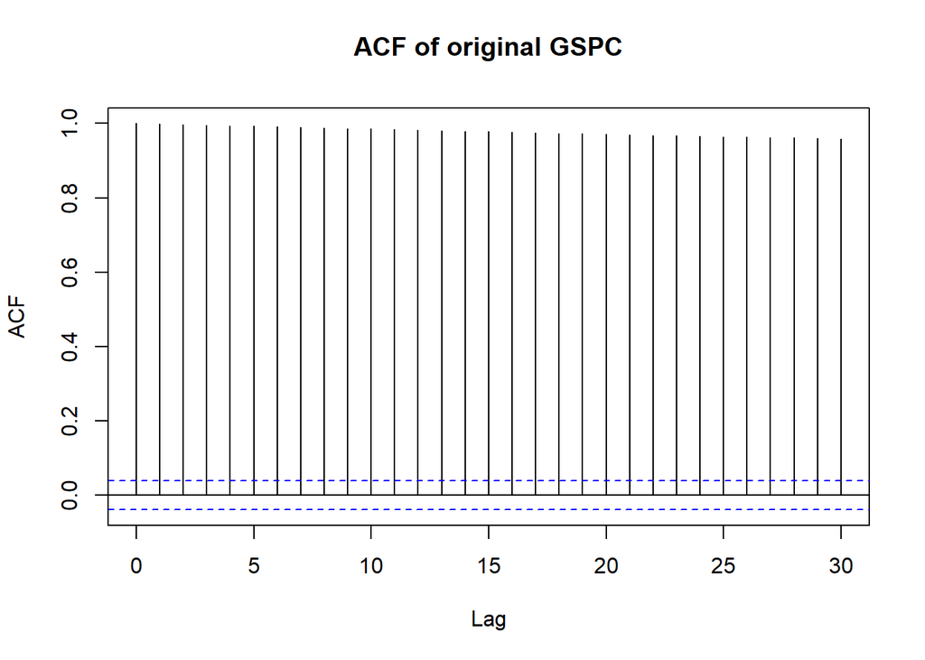

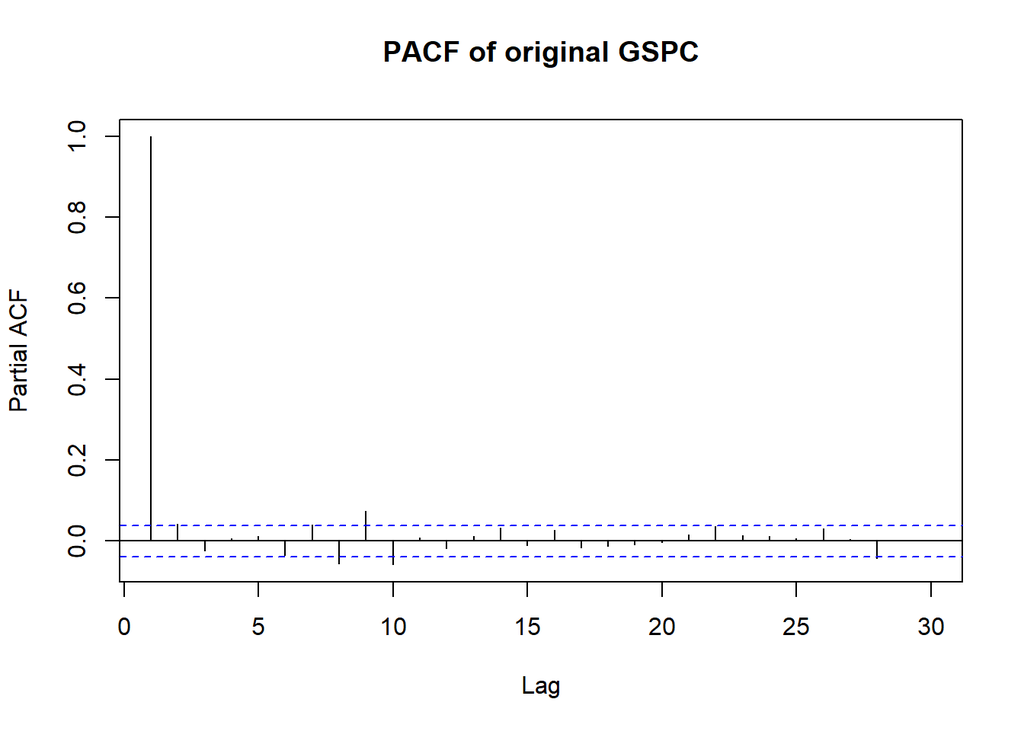

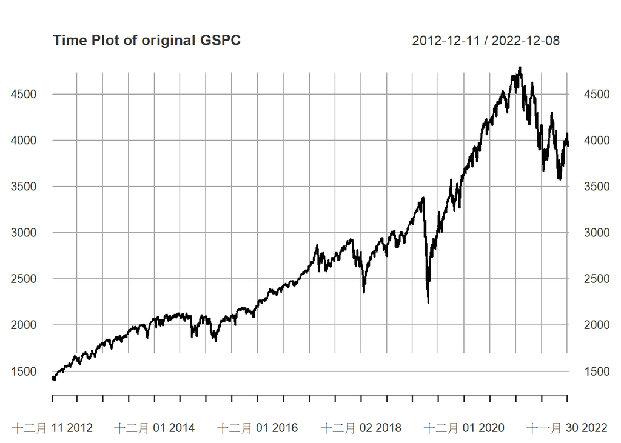

```
##
##  Box-Ljung test
##
## data:  GSPC
## X-squared = 24839, df = 10, p-value < 2.2e-16
```

```
##
##  Box-Ljung test
##
## data:  GSPC^2
## X-squared = 24838, df = 10, p-value < 2.2e-16
```

```
##
## Title:
##  Augmented Dickey-Fuller Test
##
## Test Results:
##   PARAMETER:
##     Lag Order: 1
##   STATISTIC:
##     Dickey-Fuller: -2.5195
##   P VALUE:
##     0.3584
##
## Description:
##  Mon Jan  2 16:30:43 2023 by user: User
```

## 2.4 USDJPY

```
## [1] "USDJPY=X"
```

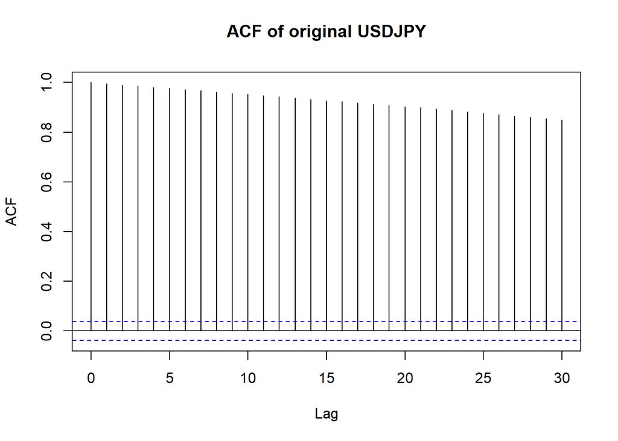

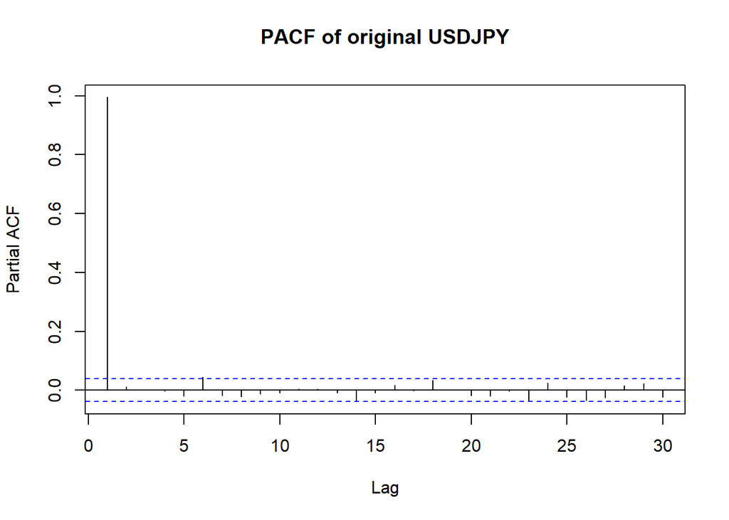

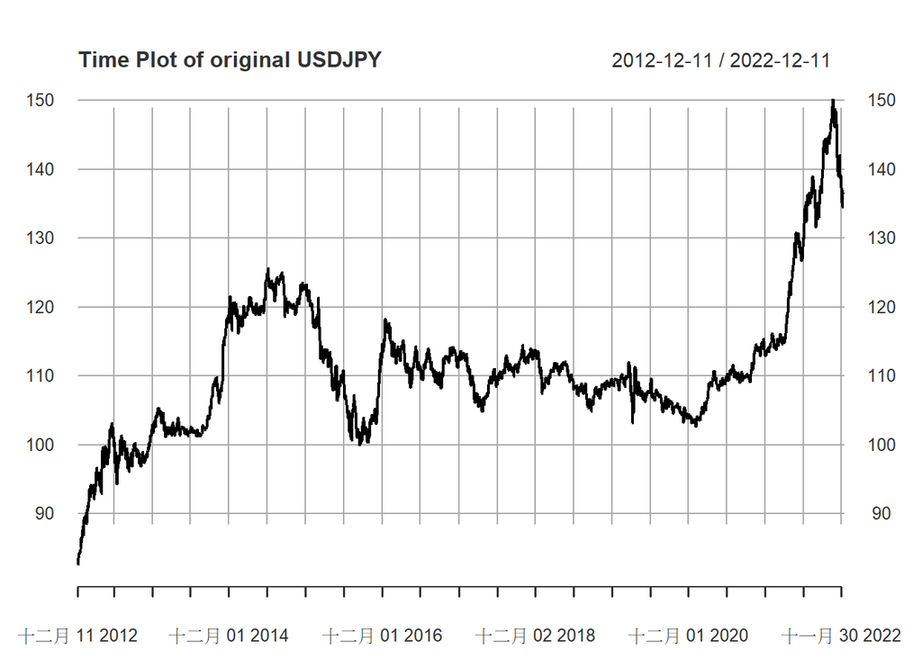

```
##
##  Box-Ljung test
##
## data:  USDJPY
## X-squared = 24780, df = 10, p-value < 2.2e-16
```

```
##
##  Box-Ljung test
##
## data:  USDJPY^2
## X-squared = 24874, df = 10, p-value < 2.2e-16
```

```
##
## Title:
##  Augmented Dickey-Fuller Test
##
## Test Results:
##   PARAMETER:
##     Lag Order: 1
##   STATISTIC:
##     Dickey-Fuller: -1.9659
##   P VALUE:
##     0.5928
##
## Description:
##  Mon Jan  2 16:30:44 2023 by user: User
```

## 2.5 N225

```
## [1] "^N225"
```

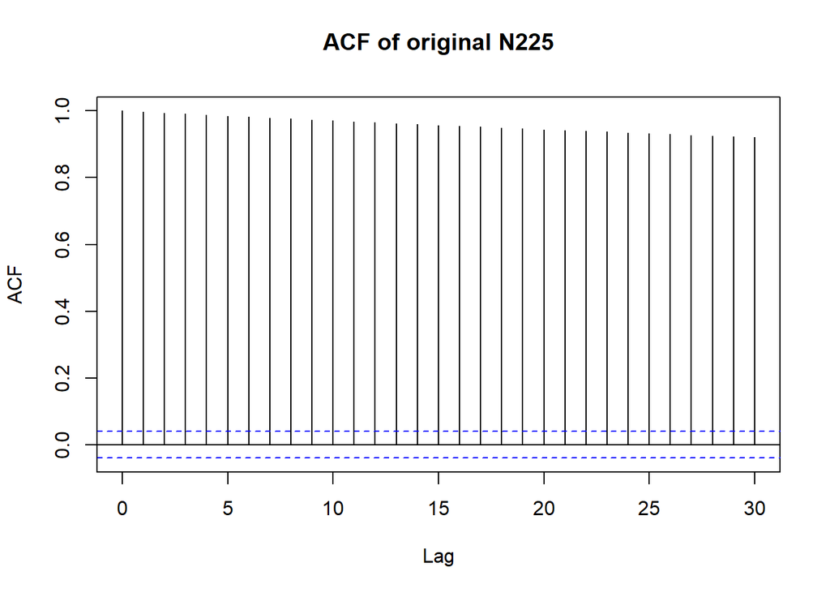

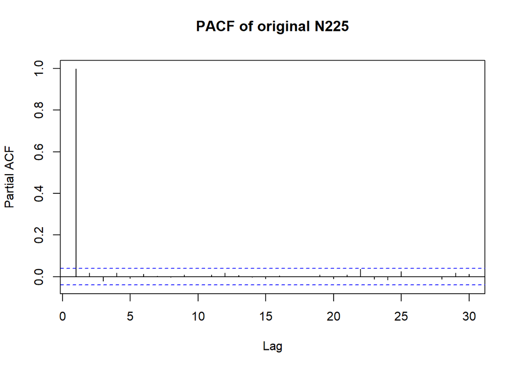

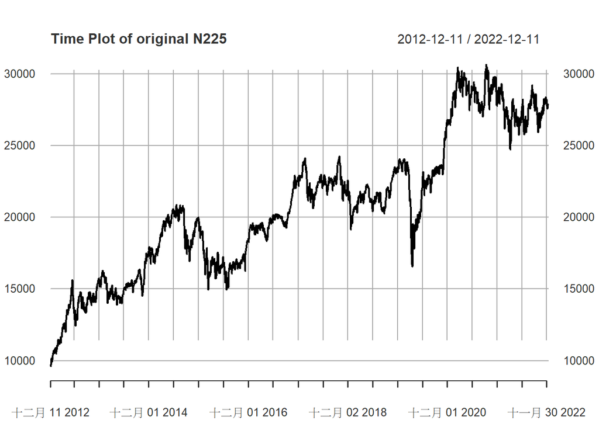

```
##
##  Box-Ljung test
##
## data:  N225
## X-squared = 23688, df = 10, p-value < 2.2e-16
```

```
##
##  Box-Ljung test
##
## data:  N225^2
## X-squared = 23742, df = 10, p-value < 2.2e-16
```

```
##
## Title:
##  Augmented Dickey-Fuller Test
##
## Test Results:
##   PARAMETER:
##     Lag Order: 1
##   STATISTIC:
##     Dickey-Fuller: -3.7242
##   P VALUE:
##     0.02277
##
## Description:
##  Mon Jan  2 16:30:45 2023 by user: User
```

## 2.6 NZDJPY

```
## [1] "NZDJPY=X"
```

[figure not shown]

[figure not shown]

[figure not shown]

```
##
##  Box-Ljung test
##
## data:  NZDJPY
## X-squared = 24766, df = 10, p-value < 2.2e-16
```

```
##
##  Box-Ljung test
##
## data:  NZDJPY^2
## X-squared = 24758, df = 10, p-value < 2.2e-16
```

```
##
## Title:
##  Augmented Dickey-Fuller Test
##
## Test Results:
##   PARAMETER:
##     Lag Order: 1
##   STATISTIC:
##     Dickey-Fuller: -2.4313
##   P VALUE:
##     0.3957
##
## Description:
##  Mon Jan  2 16:30:46 2023 by user: User
```

# 3 模型建立

將原始資料取對數後再進行差分，重新畫time plot、ACF、PACF，並做Ljung Box Test與ADF Test。 從Ljung Box Test的結果搭配對數報酬率的ACF、PACF觀察資料是否存在一階與二階序列相關，若僅存在一階序列相關可從ACF、PACF判斷ARMA(p,q)的order p與q，若ARMA(p,q)的係數不顯著則根據不顯著的係數調整ARMA(p,q)的order。 若僅存在二階序列相關可以從Garch(1,0)開始建模，並在建模後對殘差做Ljung Box Test，若以Garch(1,0)建模後的殘差存在二階相關，則嘗試以Garch(1,1)、Garch(2,1)、Garch(2,2)建模，在每次嘗試後皆對一階及二階殘差做Ljung Box Test，直至二皆殘差無序列相關即停止提升Garch(m,s)的order。 若同時存在一階與二階序列相關則結合ARMA(p,q)與Garch(m,s)進行建模，步驟與方法如上所述，同時，每次建模後若ARMA(p,q)的係數不顯著則調整ARMA(p,q)的order，若殘差的二階動差存在序列相關則調整Garch(m,s)的order。

整體來說，經過對數轉換後的資料ADF test 的p-value皆小於0.05，故無需進行差分，但在一階與二階動差的Ljung Box Test分別有不同的結果，以下將分門別類描述。

## 3.1 NZ50

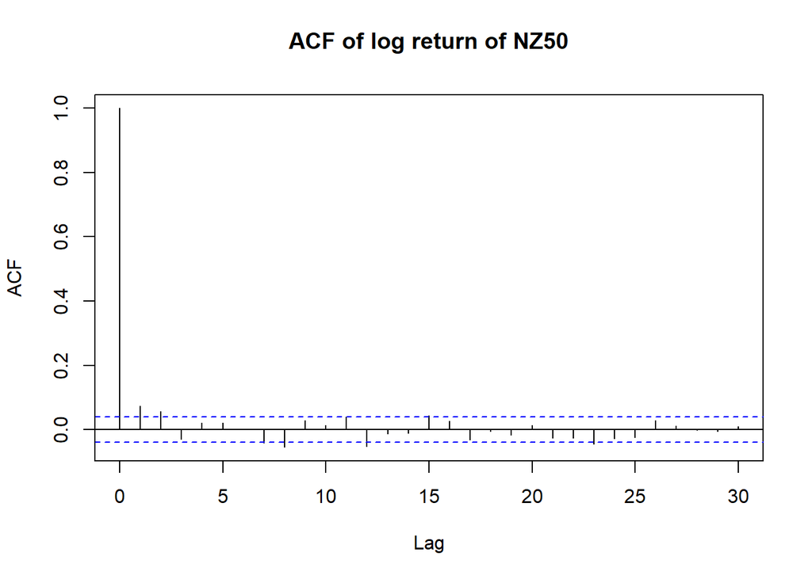

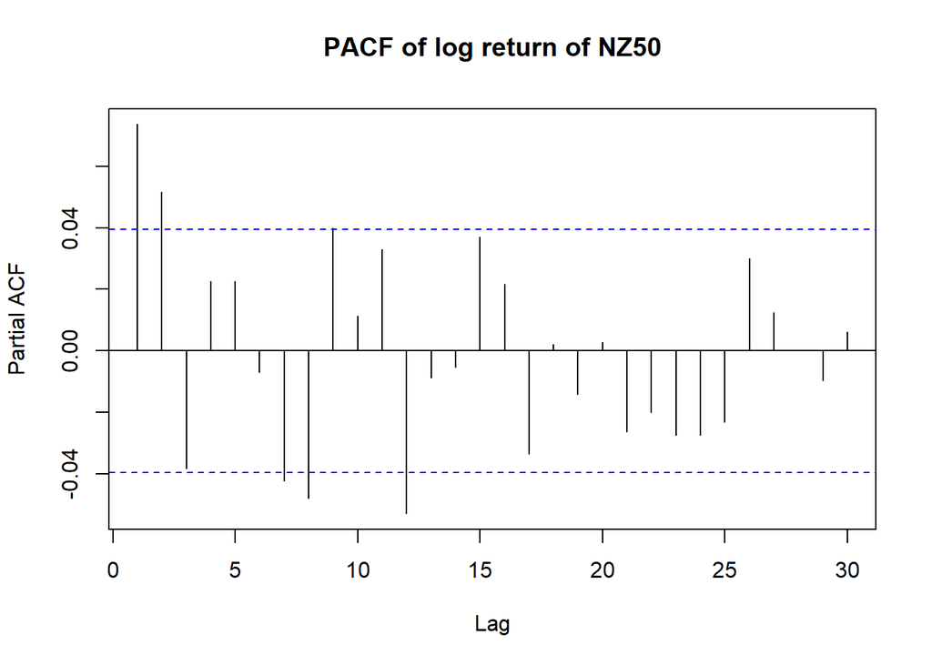

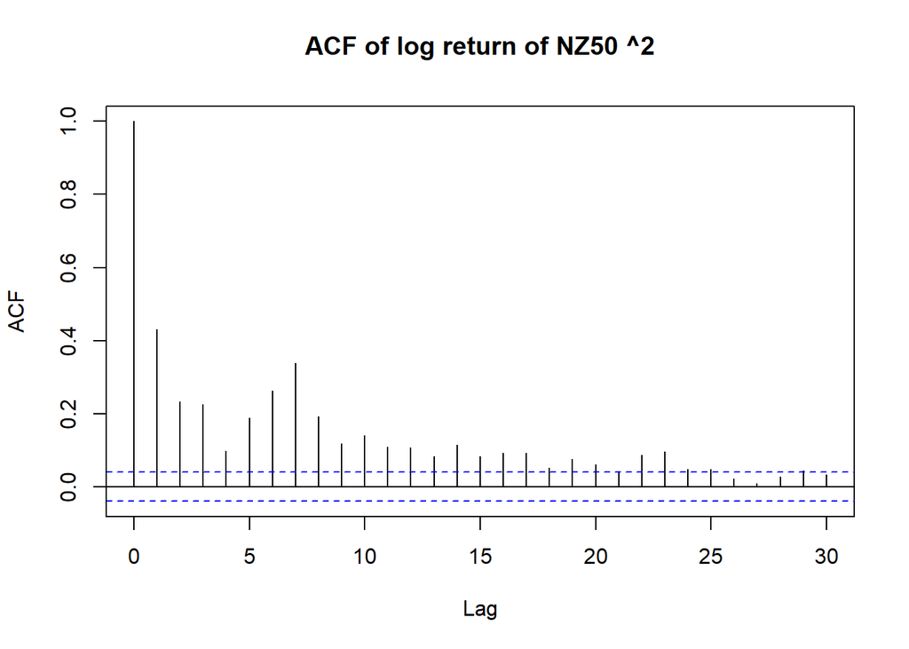

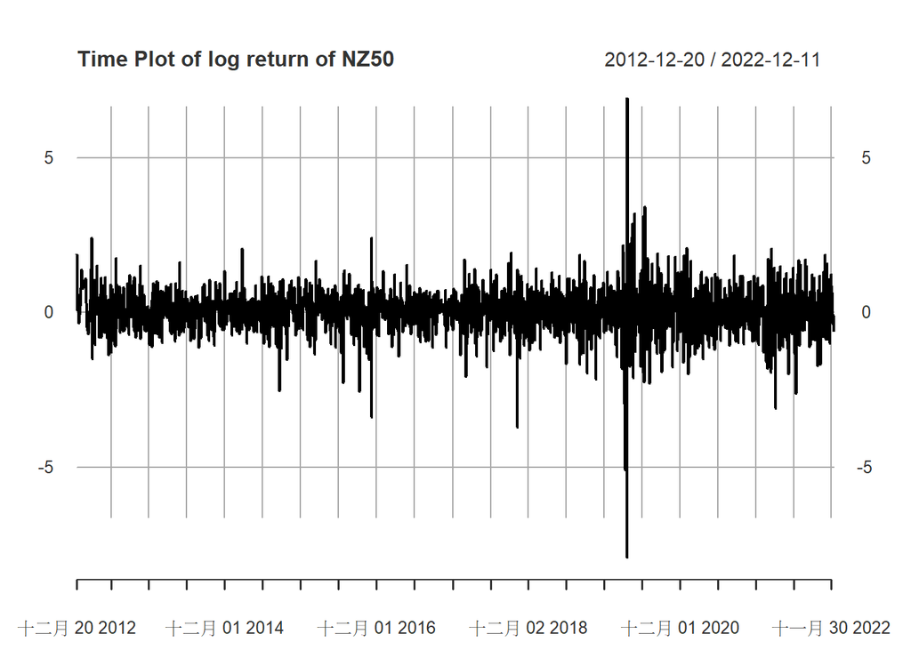

```
##
## Title:
##  Augmented Dickey-Fuller Test
##
## Test Results:
##   PARAMETER:
##     Lag Order: 1
##   STATISTIC:
##     Dickey-Fuller: -32.0558
##   P VALUE:
##     0.01
##
## Description:
##  Mon Jan  2 16:30:47 2023 by user: User
```

```
##
##  Box-Ljung test
##
## data:  logrt.NZ50
## X-squared = 39.691, df = 10, p-value = 1.921e-05
```

```
##
##  Box-Ljung test
##
## data:  logrt.NZ50^2
## X-squared = 1446.8, df = 10, p-value < 2.2e-16
```

資料經過對數轉換與差分過後皆通過ADF Test，但資料的一階動差與二階動差皆有序列相關性故我們選擇ARMA加上Garch建模。

根據對數轉換後的資料的ACF與PACF選取order p與q，找出此order之下AIC最小的模型，即NZ50在ARMA(p,q)的order p 與 q。

ARMA(p,q)order的決定先從acf/pacf plot選擇出 p & q 的最高order，再向下選出aic最低的模型，圖中可見p = 9,q = 3,故我們從(p,q)=(9,3)開始找起。 不同order下fit出的ARMA(p,q)的aic，由小到大進行排序，前三者為ARMA(4,2)、arma(5,2)、arma(4,3)。

故我們將先選用ARMA(4,2)與Garch(1,0)配適對數轉換後的資料。

### 3.1.1 Model ARMA(4,2)+Garch(1,0) and residual diagnostic

```
## $likelihood
## [1] 5343.974 5345.742 5345.796
##
## $order
##      [,1] [,2] [,3]
## [1,]    4    0    2
## [2,]    5    0    2
## [3,]    4    0    3
```

```
##
## Title:
##  GARCH Modelling
##
## Call:
##  garchFit(formula = logrt.NZ50 ~ arma(4, 2) + garch(1, 0), data = logrt.NZ50,
##     trace = FALSE)
##
## Mean and Variance Equation:
##  data ~ arma(4, 2) + garch(1, 0)
## <environment: 0x000001adfea4c330>
##  [data = logrt.NZ50]
##
## Conditional Distribution:
##  norm
##
## Coefficient(s):
##        mu        ar1        ar2        ar3        ar4        ma1        ma2
##  0.039867   0.920005  -0.976325   0.080041   0.087252  -0.785662   0.939547
##     omega     alpha1
##  0.360111   0.280077
##
## Std. Errors:
##  based on Hessian
##
## Error Analysis:
##         Estimate  Std. Error  t value Pr(>|t|)
## mu       0.03987     0.01494    2.669  0.00761 **
## ar1      0.92001     0.03685   24.969  < 2e-16 ***
## ar2     -0.97632     0.03786  -25.786  < 2e-16 ***
## ar3      0.08004     0.02625    3.049  0.00230 **
## ar4      0.08725     0.01847    4.724 2.31e-06 ***
## ma1     -0.78566     0.02416  -32.515  < 2e-16 ***
## ma2      0.93955     0.02674   35.139  < 2e-16 ***
## omega    0.36011     0.01422   25.318  < 2e-16 ***
## alpha1   0.28008     0.03693    7.585 3.33e-14 ***
## ---
## Signif. codes:  0 '***' 0.001 '**' 0.01 '*' 0.05 '.' 0.1 ' ' 1
##
## Log Likelihood:
##  -2519.92    normalized:  -1.025608
##
## Description:
##  Mon Jan  2 16:31:04 2023 by user: User
##
##
## Standardised Residuals Tests:
##                                 Statistic p-Value
##  Jarque-Bera Test   R    Chi^2  2750.893  0
##  Shapiro-Wilk Test  R    W      0.9596094 0
##  Ljung-Box Test     R    Q(10)  21.43056  0.01828348
##  Ljung-Box Test     R    Q(15)  29.33897  0.01454148
##  Ljung-Box Test     R    Q(20)  33.8512   0.02714902
##  Ljung-Box Test     R^2  Q(10)  360.1526  0
##  Ljung-Box Test     R^2  Q(15)  405.9647  0
##  Ljung-Box Test     R^2  Q(20)  447.7254  0
##  LM Arch Test       R    TR^2   263.9805  0
##
## Information Criterion Statistics:
##      AIC      BIC      SIC     HQIC
## 2.058543 2.079813 2.058516 2.066271
```

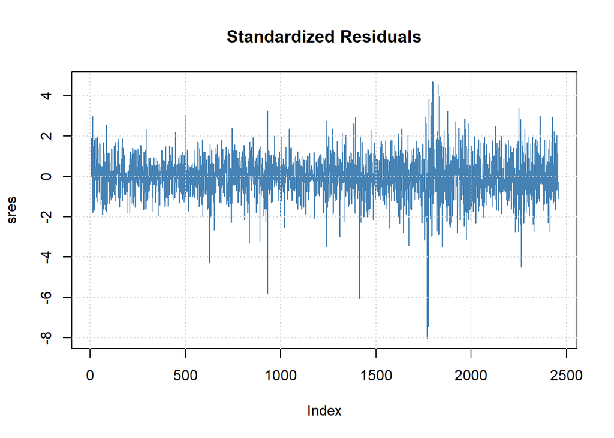

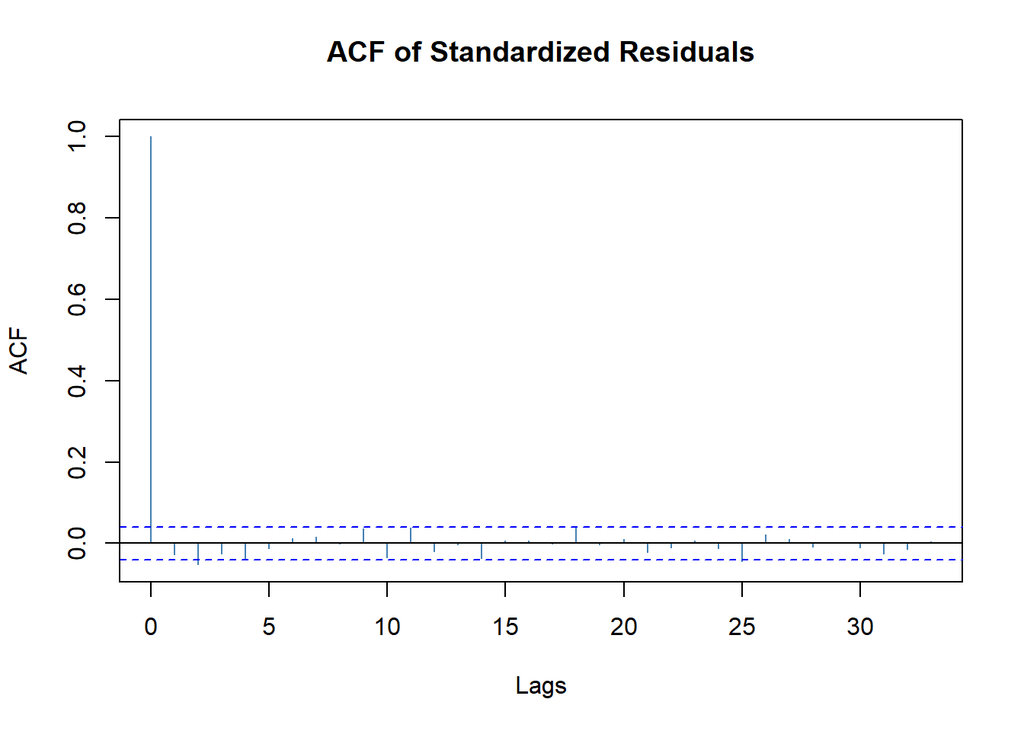

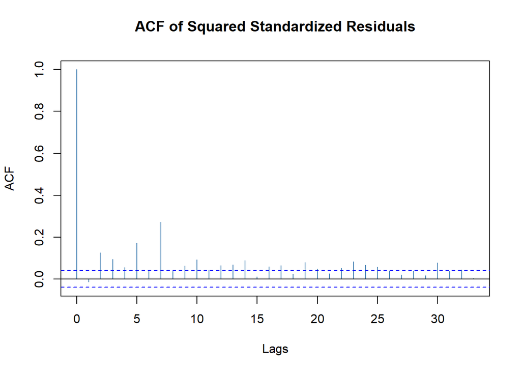

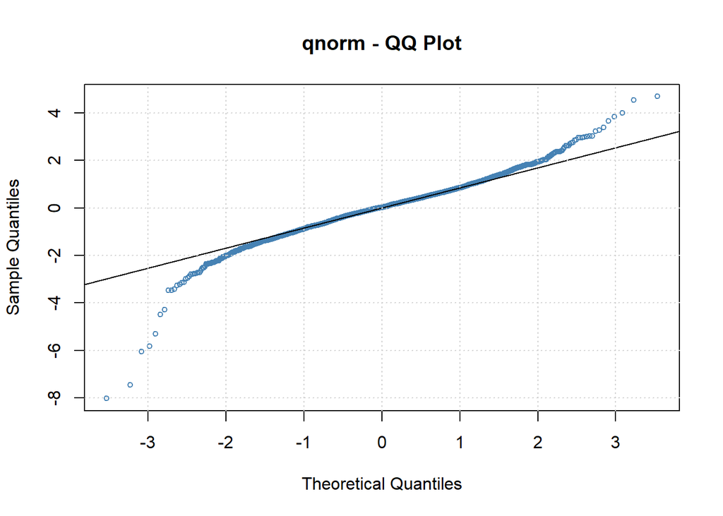

從模型配適結果來看，係數皆顯著，但殘差的二階動差有序列相關，QQ Plot厚尾，故改用ARMA(4,2)與Garch(1,1)重新配適資料。

### 3.1.2 Model ARMA(4,2)+Garch(1,1) and residual diagnostic

```
##
## Title:
##  GARCH Modelling
##
## Call:
##  garchFit(formula = logrt.NZ50 ~ arma(4, 2) + garch(1, 1), data = logrt.NZ50,
##     trace = FALSE)
##
## Mean and Variance Equation:
##  data ~ arma(4, 2) + garch(1, 1)
## <environment: 0x000001ad80ace430>
##  [data = logrt.NZ50]
##
## Conditional Distribution:
##  norm
##
## Coefficient(s):
##         mu         ar1         ar2         ar3         ar4         ma1
##  0.0641971   0.8463916  -1.0000000   0.0696780  -0.0041955  -0.7799708
##        ma2       omega      alpha1       beta1
##  0.9413657   0.0129332   0.0791814   0.8920076
##
## Std. Errors:
##  based on Hessian
##
## Error Analysis:
##         Estimate  Std. Error  t value Pr(>|t|)
## mu      0.064197    0.013800    4.652 3.29e-06 ***
## ar1     0.846392    0.049474   17.108  < 2e-16 ***
## ar2    -1.000000    0.051225  -19.522  < 2e-16 ***
## ar3     0.069678    0.027557    2.528 0.011456 *
## ar4    -0.004195    0.020894   -0.201 0.840853
## ma1    -0.779971    0.048161  -16.195  < 2e-16 ***
## ma2     0.941366    0.049815   18.897  < 2e-16 ***
## omega   0.012933    0.003905    3.312 0.000926 ***
## alpha1  0.079181    0.012618    6.275 3.49e-10 ***
## beta1   0.892008    0.018862   47.291  < 2e-16 ***
## ---
## Signif. codes:  0 '***' 0.001 '**' 0.01 '*' 0.05 '.' 0.1 ' ' 1
##
## Log Likelihood:
##  -2349.091    normalized:  -0.9560809
##
## Description:
##  Mon Jan  2 16:31:06 2023 by user: User
##
##
## Standardised Residuals Tests:
##                                 Statistic p-Value
##  Jarque-Bera Test   R    Chi^2  288.0483  0
##  Shapiro-Wilk Test  R    W      0.9873287 5.695411e-14
##  Ljung-Box Test     R    Q(10)  5.002079  0.8910391
##  Ljung-Box Test     R    Q(15)  11.75271  0.6976422
##  Ljung-Box Test     R    Q(20)  13.3118   0.8636088
##  Ljung-Box Test     R^2  Q(10)  9.162465  0.5167577
##  Ljung-Box Test     R^2  Q(15)  13.75105  0.544488
##  Ljung-Box Test     R^2  Q(20)  15.32487  0.7575263
##  LM Arch Test       R    TR^2   10.72785  0.5523746
##
## Information Criterion Statistics:
##      AIC      BIC      SIC     HQIC
## 1.920302 1.943935 1.920269 1.928889
```

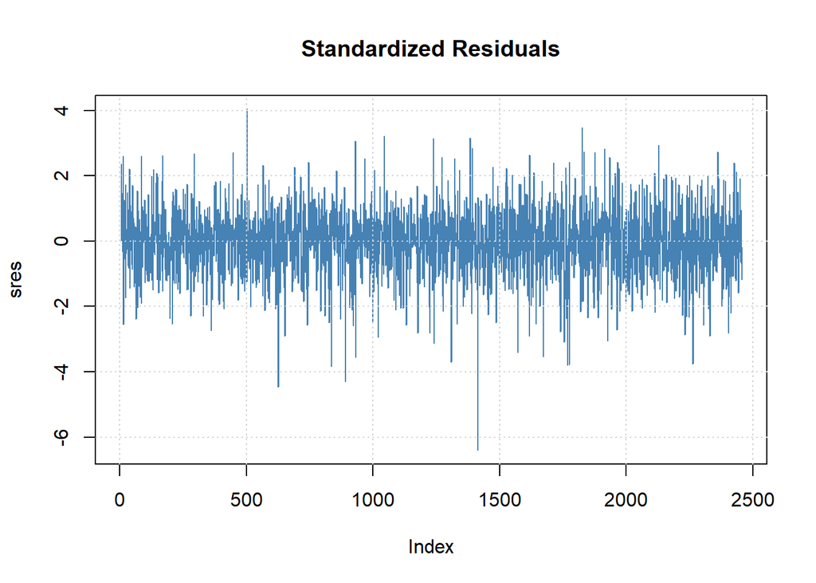

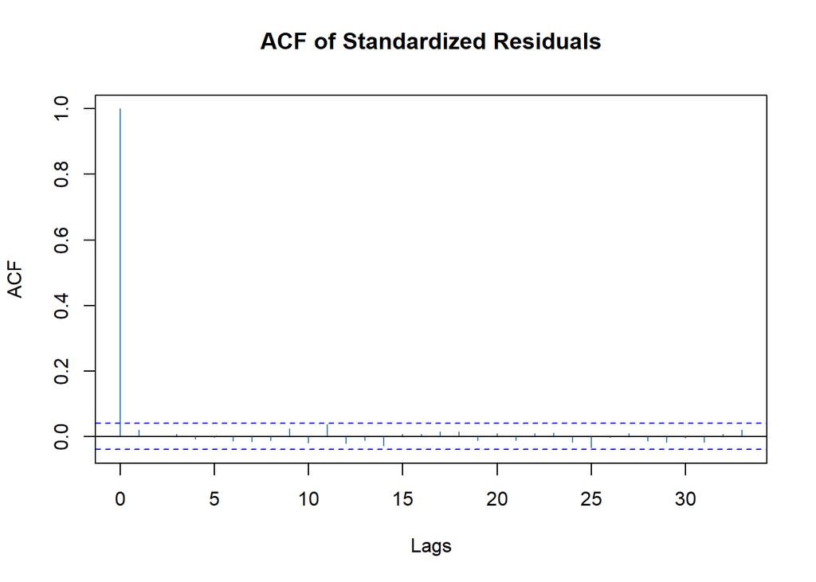

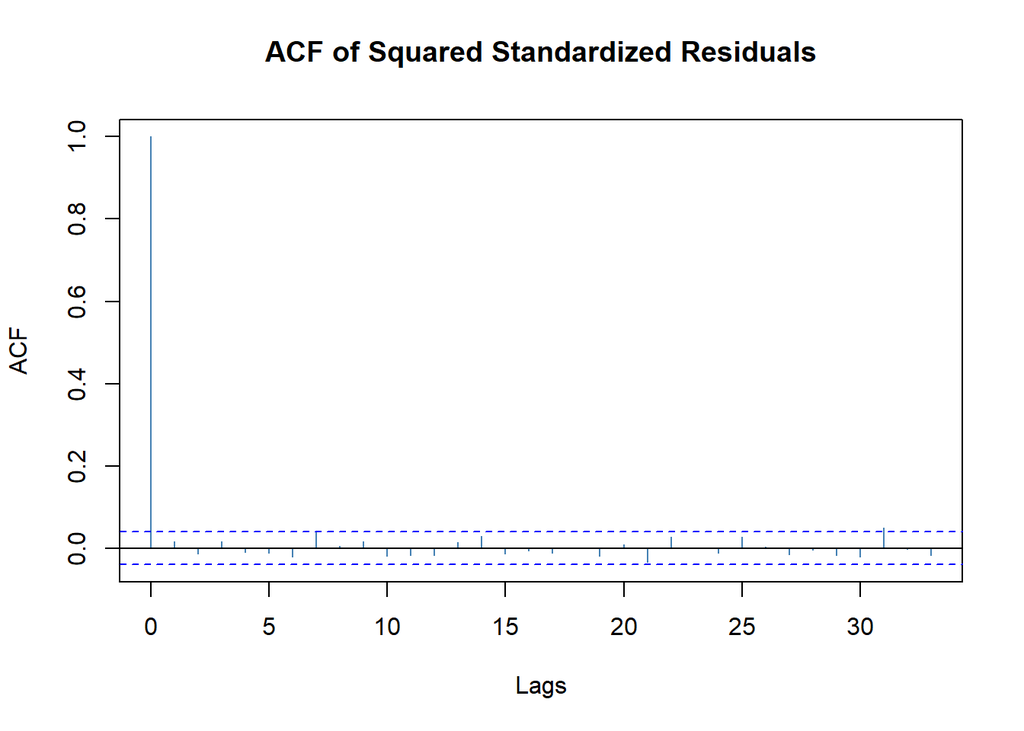

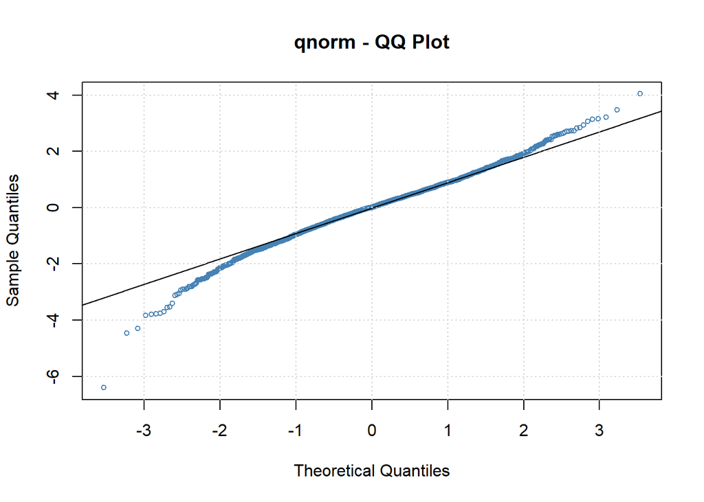

ARMA(4,2)與Garch(1,1)配適後，僅有AR4的係數不顯著，其餘皆十分顯著，且殘差一階動差與二階動差皆無序列相關，但從QQ Plot來看，資料呈現厚尾的現象，且常態檢定Shapiro Test拒絕虛無假設，表示殘差非常態分配，故改配適假設殘差來自標準 T分配的ARMA(3,2)與Garch(1,1)的模型。